# **Vanilla CNN and Fine-Tune VGG16 - for Dogs and Cats Classification**

# **Problem Statement**

#### The objective of this report is to generate a vanilla CNN and fine-tune existing model VGG16 for Dogs and Cats Classification and evaluate both the models.

## **Importing Libraries**

```python
from tensorflow import keras
from tensorflow.keras import layers
import pathlib
from tensorflow.keras.utils import image_dataset_from_directory
from keras.preprocessing.image import ImageDataGenerator
from keras.callbacks import ModelCheckpoint
import matplotlib.pyplot as plt
import numpy as np
from keras.models import load_model
from keras.layers import Dropout
import os, glob

# performance metrics
from sklearn.metrics import confusion_matrix, precision_score, recall_score, f1_score, precision_recall_curve, roc_curve, roc_auc_score,  classification_report, accuracy_score
```

## Asirra: The Dogs vs. Cats Dataset

The dataset is obtained from Kaggle : [The Dataset](https://www.kaggle.com/datasets/biaiscience/dogs-vs-cats) (with an Open Data license). Asirra (Animal Species Image Recognition for Restricting Access) is a CAPTCHA that works by asking users to identify photographs of cats and dogs. The dataset has **25,000** images, of about 600MB . Here we have created a subset of this dataset consisting of 1000 training images, 500 validation images and 1000 test images *per class*. This reduces the dataset from 25,000 images to 5000.

```python
import os, shutil, pathlib
import os

original_dir = pathlib.Path("./data/kaggle_dogs_vs_cats/train/train")
new_base_dir = pathlib.Path("./data/kaggle_dogs_vs_cats_small")

def make_subset(subset_name, start_index, end_index):
    for category in ("cat", "dog"):
        dir = new_base_dir / subset_name / category
        os.makedirs(dir)
        fnames = [f"{category}.{i}.jpg" for i in range(start_index, end_index)]
        for fname in fnames:
            shutil.copyfile(src=original_dir / fname,
                            dst=dir / fname)

make_subset("train", start_index=0, end_index=1000)
make_subset("validation", start_index=1000, end_index=1500)
make_subset("test", start_index=1500, end_index=2500)
```

```python
# Defining the data folder
data_folder = pathlib.Path('./data/kaggle_dogs_vs_cats_small')
```

```python
# Loading the datasets
# training set
train_dataset = image_dataset_from_directory(
    data_folder / "train",
    image_size=(180, 180),
    batch_size=32,
    label_mode='binary')
# validation set
validation_dataset = image_dataset_from_directory(
    data_folder / "validation",
    image_size=(180, 180),
    batch_size=32,
    label_mode='binary')
# test set
test_dataset = image_dataset_from_directory(
    data_folder / "test",
    image_size=(180, 180),
    batch_size=32,
    label_mode='binary')
```

```
Found 2000 files belonging to 2 classes.
Found 1000 files belonging to 2 classes.
Found 2000 files belonging to 2 classes.
```

The subset consists of 1000 training images, 500 validation images, and 1000 test images per class.

## **Exploring the Data**

```python
for features, labels in train_dataset:
    # Print the shape of the data batch
    print("data shape:", features.shape)

    # Print the shape of the labels
    print("labels shape:", labels.shape)
    break
```

```
data shape: (32, 180, 180, 3)
labels shape: (32, 1)
```

Each batch contains 32 images, each of size 180x180 and with 3 color channels (RGB). The labels for each batch are also in a batch of 32.

```python
# print the labels of the images in the first batch
labels
```

```
<tf.Tensor: shape=(32, 1), dtype=float32, numpy=
array([[1.],
       [1.],
       [1.],
       [0.],
       [0.],
       [0.],
       [0.],
       [0.],
       [1.],
       [0.],
       [1.],
       [1.],
       [0.],
       [0.],
       [1.],
       [1.],
       [0.],
       [0.],
       [1.],
       [1.],
       [1.],
       [0.],
       [1.],
       [1.],
       [0.],
       [1.],
       [1.],
       [1.],
       [1.],
       [0.],
       [0.],
       [0.]], dtype=float32)>
```

1 represents 'dog' and 0 represents 'cat'.

```python
# Get the class names
class_names = train_dataset.class_names
print(class_names)
```

```
['cat', 'dog']
```

### **Visualize first few images in a batch to understand the structure and content of the dataset.**

[Reference](https://www.kaggle.com/code/kokyongteo/dogs-vs-cats-base-model-vs-vgg16?scriptVersionId=91565671&cellId=25)

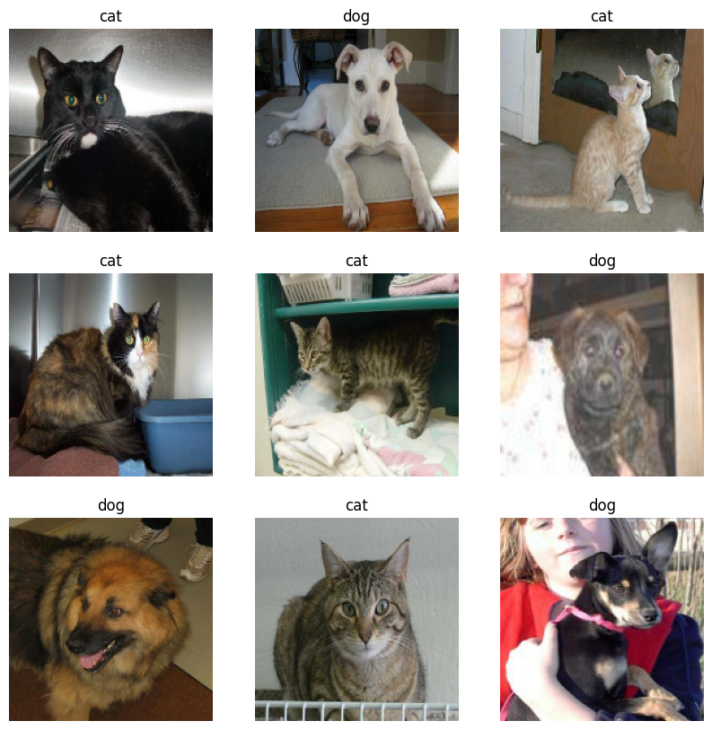

```python
plt.figure(figsize=(10, 10))
for images, labels in train_dataset.take(1):
  for i in range(9):
    ax = plt.subplot(3, 3, i + 1)
    ax.imshow(images[i].numpy().astype("uint8"))
    ax.set_title(class_names[int(labels[i])])
    ax.axis("off")
plt.show()
```

All the images are labeled correctly

### **Check class distribution**

```python
class_counts = {name: 0 for name in class_names}
for images, labels in train_dataset:
    for label in labels:
        label = int(label)
        class_counts[class_names[label]] += 1

print(class_counts)
```

```
{'cat': 1000, 'dog': 1000}
```

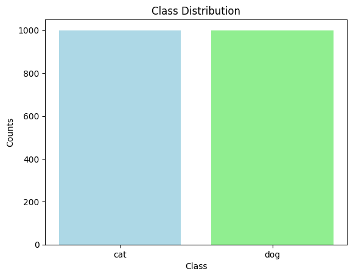

```python
plt.bar(class_counts.keys(), class_counts.values(), color=['lightblue', 'lightgreen'])

plt.title('Class Distribution')
plt.xlabel('Class')
plt.ylabel('Counts')
plt.show()
```

Observations :

- The distribution of classes is balanced

# **Define the models**

Define a vanilla CNN model with multiple convolutional and max pooling layers, followed by a dense layer and a dropout layer to prevent overfitting. The output layer uses a sigmoid activation function for binary classification.

```python
inputs = keras.Input(shape=(180, 180, 3))
x = layers.Rescaling(1./255)(inputs)
x = layers.Conv2D(filters=32, kernel_size=3, activation="relu")(x)
x = layers.MaxPooling2D(pool_size=2)(x)
x = layers.Conv2D(filters=64, kernel_size=3, activation="relu")(x)
x = layers.MaxPooling2D(pool_size=2)(x)
x = layers.Conv2D(filters=128, kernel_size=3, activation="relu")(x)
x = layers.MaxPooling2D(pool_size=2)(x)
x = layers.Conv2D(filters=256, kernel_size=3, activation="relu")(x)
x = layers.MaxPooling2D(pool_size=2)(x)
x = layers.Conv2D(filters=256, kernel_size=3, activation="relu")(x)
x = layers.Dense(512, activation='relu')(x)
x = layers.Flatten()(x)
x = Dropout(0.5)(x)
outputs = layers.Dense(1, activation="sigmoid")(x)
model_Vanilla_CNN = keras.Model(inputs=inputs, outputs=outputs)
```

**Instantiating the VGG16 convolutional base**

The VGG16 model is pre-trained on the ImageNet dataset. The weights of this model are loaded and the top dense layer is not included.

```python
conv_base = keras.applications.vgg16.VGG16(
    weights="imagenet",
    include_top=False,
    input_shape=(180, 180, 3))
```

The layers of this model are frozen to prevent them getting updated during training.

```python
conv_base.trainable = False
```

```python
conv_base.summary()
```

```
Model: "vgg16"
_________________________________________________________________
 Layer (type)                Output Shape              Param #
=================================================================
 input_2 (InputLayer)        [(None, 180, 180, 3)]     0

 block1_conv1 (Conv2D)       (None, 180, 180, 64)      1792

 block1_conv2 (Conv2D)       (None, 180, 180, 64)      36928

 block1_pool (MaxPooling2D)  (None, 90, 90, 64)        0

 block2_conv1 (Conv2D)       (None, 90, 90, 128)       73856

 block2_conv2 (Conv2D)       (None, 90, 90, 128)       147584

 block2_pool (MaxPooling2D)  (None, 45, 45, 128)       0

 block3_conv1 (Conv2D)       (None, 45, 45, 256)       295168

 block3_conv2 (Conv2D)       (None, 45, 45, 256)       590080

 block3_conv3 (Conv2D)       (None, 45, 45, 256)       590080

 block3_pool (MaxPooling2D)  (None, 22, 22, 256)       0

 block4_conv1 (Conv2D)       (None, 22, 22, 512)       1180160

 block4_conv2 (Conv2D)       (None, 22, 22, 512)       2359808

 block4_conv3 (Conv2D)       (None, 22, 22, 512)       2359808

 block4_pool (MaxPooling2D)  (None, 11, 11, 512)       0

 block5_conv1 (Conv2D)       (None, 11, 11, 512)       2359808

 block5_conv2 (Conv2D)       (None, 11, 11, 512)       2359808

 block5_conv3 (Conv2D)       (None, 11, 11, 512)       2359808

 block5_pool (MaxPooling2D)  (None, 5, 5, 512)         0

=================================================================
Total params: 14,714,688
Trainable params: 0
Non-trainable params: 14,714,688
_________________________________________________________________
```

The model has 14,714,688 parameters, all of which are non-trainable as the model has been frozen to preserve the pre-trained weights.

### Extracting Features and Labels :

The use of the pre-trained VGG16 base model for feature extraction is a form of transfer learning

```python
import numpy as np

def get_features_and_labels(dataset):
    all_features = []
    all_labels = []
    for images, labels in dataset:

        # Using the VGG16 preprocess_input function to preprocess the images
        preprocessed_images = keras.applications.vgg16.preprocess_input(images)

        # Using the VGG16 base model to predict the features of the preprocessed images
        features = conv_base.predict(preprocessed_images)
        all_features.append(features)
        all_labels.append(labels)
    return np.concatenate(all_features), np.concatenate(all_labels)

# Get the features and labels for the training, validation, and test datasets
train_features, train_labels =  get_features_and_labels(train_dataset)
val_features, val_labels =  get_features_and_labels(validation_dataset)
test_features, test_labels =  get_features_and_labels(test_dataset)
```

Defining a model that takes the features extracted by the VGG16 base model as input and outputs predictions for classifying images of dogs and cats. The model consists of a flatten layer, a dense layer with 256 units, a dropout layer with a rate of 0.5 to prevent overfitting, and an output layer with a sigmoid activation function for binary classification.

```python
inputs = keras.Input(shape=(5, 5, 512))
x = layers.Flatten()(inputs)
x = layers.Dense(256)(x)
x = layers.Dropout(0.5)(x)
outputs = layers.Dense(1, activation="sigmoid")(x)
model_VGG16 = keras.Model(inputs, outputs)
```

```python
model_VGG16.summary()
```

```
Model: "model_1"
_________________________________________________________________
 Layer (type)                Output Shape              Param #
=================================================================
 input_3 (InputLayer)        [(None, 5, 5, 512)]       0

 flatten_1 (Flatten)         (None, 12800)             0

 dense_2 (Dense)             (None, 256)               3277056

 dropout_1 (Dropout)         (None, 256)               0

 dense_3 (Dense)             (None, 1)                 257

=================================================================
Total params: 3,277,313
Trainable params: 3,277,313
Non-trainable params: 0
_________________________________________________________________
```

The summary shows that the model takes an input of shape (5, 5, 512), which is the output shape of the VGG16 base model, flattens the input and passes it through a dense layer with 256 units. Dropout layer is applied to prevent overfitting. Model has a total of 3,277,313 trainable parameters

## **Define the Loss Function, Optimizer and Metrics**

Compiling the model, defining a loss function and metrics

```python
# Configure the neural network model for training
model_Vanilla_CNN.compile(optimizer="rmsprop",
              loss="binary_crossentropy",
              metrics=["accuracy"])
```

```python
model_VGG16.compile(loss="binary_crossentropy",
              optimizer="rmsprop",
              metrics=["accuracy"])
```

Setting up a ModelCheckpoint callback for each model to save the model weights whenever the validation loss improves

```python
# Save the best model
model_CNN_checkpoint_callback = ModelCheckpoint(filepath='./models/best_CNN_model.h5', save_best_only=True, monitor='val_loss', mode='min')
```

```python
model_VGG16_checkpoint_callback = [
    keras.callbacks.ModelCheckpoint(
      filepath="./models/fine_tuning_VGG16_model.keras",
      save_best_only=True,
      monitor="val_loss")
]
```

## **Training ("Fitting") the model**

Vanilla CNN model is trained for 20 epochs on the train_dataset with validation on the validation_dataset and monitored by model_CNN_checkpoint_callback call back

```python
history_model_CNN = model_Vanilla_CNN.fit(train_dataset, epochs=20, validation_data=validation_dataset, callbacks=model_CNN_checkpoint_callback)
```

VGG16 model is trained for 20 epochs on the train_dataset with validation on the validation_dataset and monitored by model_VGG16_checkpoint_callback call back

```python
history_model_VGG16 = model_VGG16.fit(
    train_features, train_labels,
    epochs=20,
    validation_data=(val_features, val_labels),
    callbacks=model_VGG16_checkpoint_callback)
```

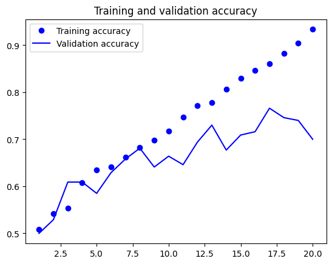

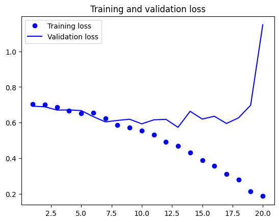

```python
accuracy = history_model_CNN.history["accuracy"]
val_accuracy = history_model_CNN.history["val_accuracy"]
loss = history_model_CNN.history["loss"]
val_loss = history_model_CNN.history["val_loss"]
epochs = range(1, len(accuracy) + 1)
plt.plot(epochs, accuracy, "bo", label="Training accuracy")
plt.plot(epochs, val_accuracy, "b", label="Validation accuracy")
plt.title("Training and validation accuracy")
plt.legend()
plt.figure()
plt.plot(epochs, loss, "bo", label="Training loss")
plt.plot(epochs, val_loss, "b", label="Validation loss")
plt.title("Training and validation loss")
plt.legend()
plt.show()
```

The best set of weights to avoid overfitting for the vanilla CNN model would be epoch 13. This is where the validation loss is at its lowest. After this point, the validation loss starts to increase while training loss continues to decrease, indicating overfitting.

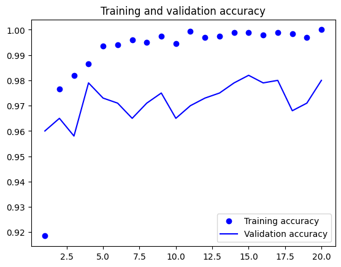

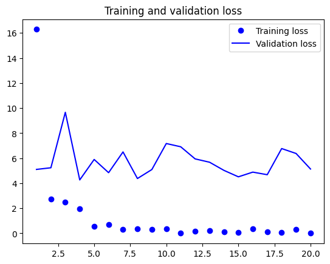

```python
acc = history_model_VGG16.history["accuracy"]
val_acc = history_model_VGG16.history["val_accuracy"]
loss = history_model_VGG16.history["loss"]
val_loss = history_model_VGG16.history["val_loss"]
epochs = range(1, len(acc) + 1)
plt.plot(epochs, acc, "bo", label="Training accuracy")
plt.plot(epochs, val_acc, "b", label="Validation accuracy")
plt.title("Training and validation accuracy")
plt.legend()
plt.figure()
plt.plot(epochs, loss, "bo", label="Training loss")
plt.plot(epochs, val_loss, "b", label="Validation loss")
plt.title("Training and validation loss")
plt.legend()
plt.show()
```

The best set of weights to avoid overfitting for the VGG16 model would be epoch 4. This is where the validation loss is at its lowest. After this point, the validation loss starts to increase while training loss continues to decrease, indicating overfitting.

```python
# Load the best models for each of the cases
best_model_CNN = load_model('best_CNN_model.h5')
best_model_VGG16 = load_model("./models/fine_tuning_VGG16_model.keras")
```

## **Best Model Evaluation on Validation Set**

```python
val_loss_model_CNN, val_acc_model_CNN = best_model_CNN.evaluate(validation_dataset)
print(f"Vanilla CNN validation accuracy:: {val_acc_model_CNN:3f}")

val_loss_model_VGG16, val_acc_model_VGG16 = best_model_VGG16.evaluate(val_features,val_labels)
print(f"Fine tuning VGG16 validation accuracy:: {val_acc_model_VGG16:3f}")
```

```
Vanilla CNN validation accuracy:: 0.600000
Fine tuning VGG16 validation accuracy:: 0.979000
```

```python
val_pred_model_CNN= best_model_CNN.predict(validation_dataset)
acc_CNN = accuracy_score(val_labels, np.round(val_pred_model_CNN))*100
cm_CNN = confusion_matrix(val_labels, np.round(val_pred_model_CNN))
tn, fp, fn, tp = cm_CNN.ravel()

print('\n============Validation Metrics=============')
precision = tp/(tp+fp)*100
recall = tp/(tp+fn)*100
print('Accuracy: {}%'.format(acc_CNN))
print('Precision: {}%'.format(precision))
print('Recall: {}%'.format(recall))
print('F1-score: {}'.format(2*precision*recall/(precision+recall)))
print('Confusion Metric  : {}'.format(cm_CNN))
```

```
============Validation Metrics=============
Accuracy: 47.599999999999994%
Precision: 47.379912663755455%
Recall: 43.4%
F1-score: 45.3027139874739
Confusion Metric  : [[259 241]
 [283 217]]
```

```python
val_pred_model_VGG16= best_model_VGG16.predict(val_features)
acc_VGG16 = accuracy_score(val_labels, np.round(val_pred_model_VGG16))*100
cm_VGG16 = confusion_matrix(val_labels, np.round(val_pred_model_VGG16))
tn, fp, fn, tp = cm_VGG16.ravel()

print('\n============Validation Metrics=============')
precision = tp/(tp+fp)*100
recall = tp/(tp+fn)*100
print('Accuracy: {}%'.format(acc_VGG16))
print('Precision: {}%'.format(precision))
print('Recall: {}%'.format(recall))
print('F1-score: {}'.format(2*precision*recall/(precision+recall)))
print('Confusion Metric  : {}'.format(cm_VGG16))
```

```
============Validation Metrics=============
Accuracy: 97.89999999999999%
Precision: 98.58012170385395%
Recall: 97.2%
F1-score: 97.88519637462235
Confusion Metric  : [[493   7]
 [ 14 486]]
```

Observations : The accuracy of the model on the validation set is 97.8%. Also Model has achieved high precision recall and F1-score, which suggests that it has a good performance on the validation set.

Conclusion :

Here Fine-tuned VGG16 model clearly outperforms the Vanilla CNN model on the validation set due to the transfer learning, where the VGG16 model has been pre-trained on ImageNet dataset and then fine-tuned on the task of classifying images of dogs and cats.

## **Best Model Evaluation on Test Set**

```python
test_pred_model_VGG16 = best_model_VGG16.predict(test_features)
acc_test_VGG16 = accuracy_score(test_labels, np.round(test_pred_model_VGG16))*100
cm_test_VGG16 = confusion_matrix(test_labels, np.round(test_pred_model_VGG16))
tn, fp, fn, tp = cm_test_VGG16.ravel()

print('\n============TEST METRICS=============')
precision = tp/(tp+fp)*100
recall = tp/(tp+fn)*100
print('Accuracy: {}%'.format(acc_test_VGG16))
print('Precision: {}%'.format(precision))
print('Recall: {}%'.format(recall))
print('F1-score: {}'.format(2*precision*recall/(precision+recall)))
print('Confusion Metric  : {}'.format(cm_test_VGG16))
```

```
============TEST METRICS=============
Accuracy: 97.35000000000001%
Precision: 98.16887080366226%
Recall: 96.5%
F1-score: 97.32728189611699
Confusion Metric  : [[982  18]
 [ 35 965]]
```

Conclusions on Test Set :

- The VGG16 model achieved an accuracy of approximately 97.35% on the test set which is comparable to the accuracy achieved for validation set.
- Considering the Precision, Recall and F1 score, the model’s performance on the test set is consistent with its performance on the validation set.